# IODS course project

### 1. Alcohol use and study time

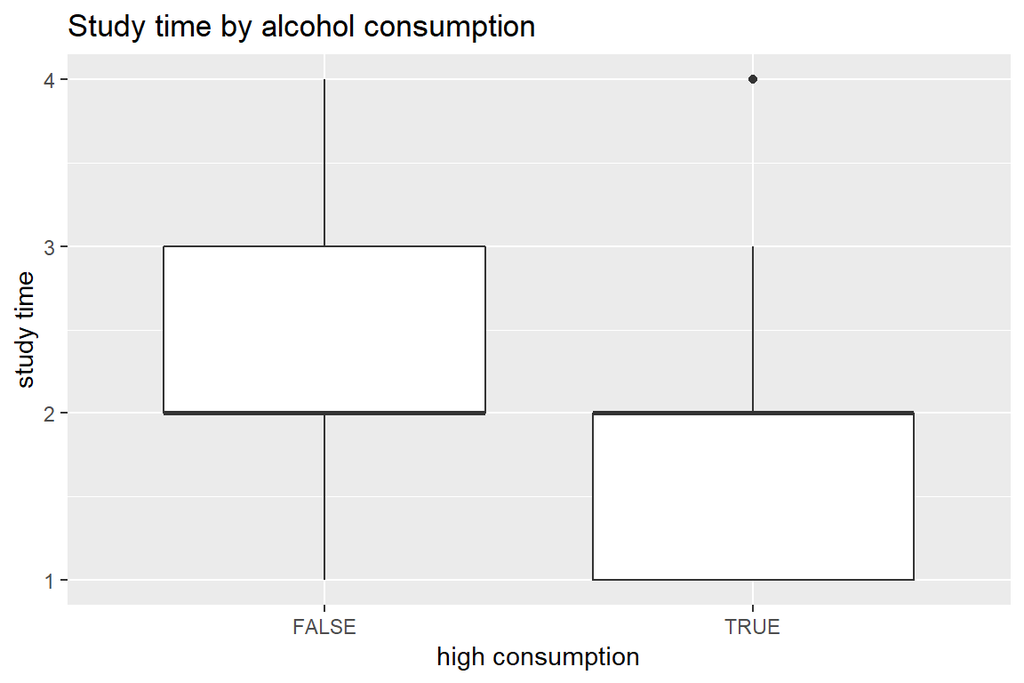

```r
g1 <- ggplot(chapter3analysis, aes(x = high_use, y = studytime))

g1 + geom_boxplot() + ggtitle("Study time by alcohol consumption") + ylab("study time") + xlab("high consumption")
```

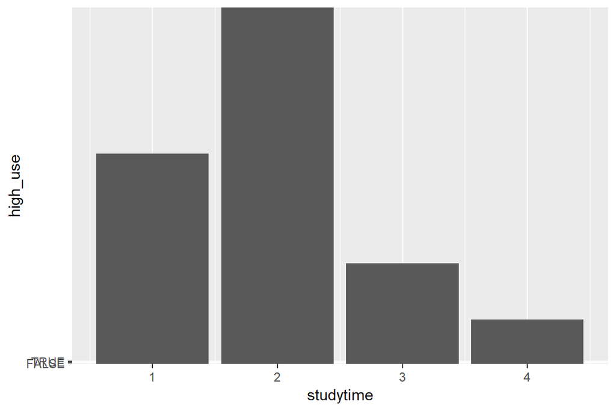

```r
gg1 <-ggplot(data=chapter3analysis, aes(x=studytime, y=high_use)) +
  geom_bar(stat="identity")
gg1
```

```r
table(high_use = chapter3analysis$high_use, studytime = chapter3analysis$studytime)
```

```
##         studytime
## high_use   1   2   3   4
##    FALSE  60 133  54  23
##    TRUE   43  57   8   4
```

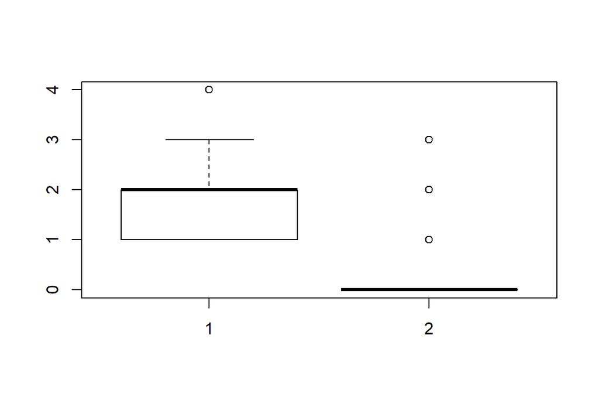

```r
boxplot(chapter3analysis$studytime, chapter3analysis$failures)
```

### 2. Alcohol use and study and past class failures

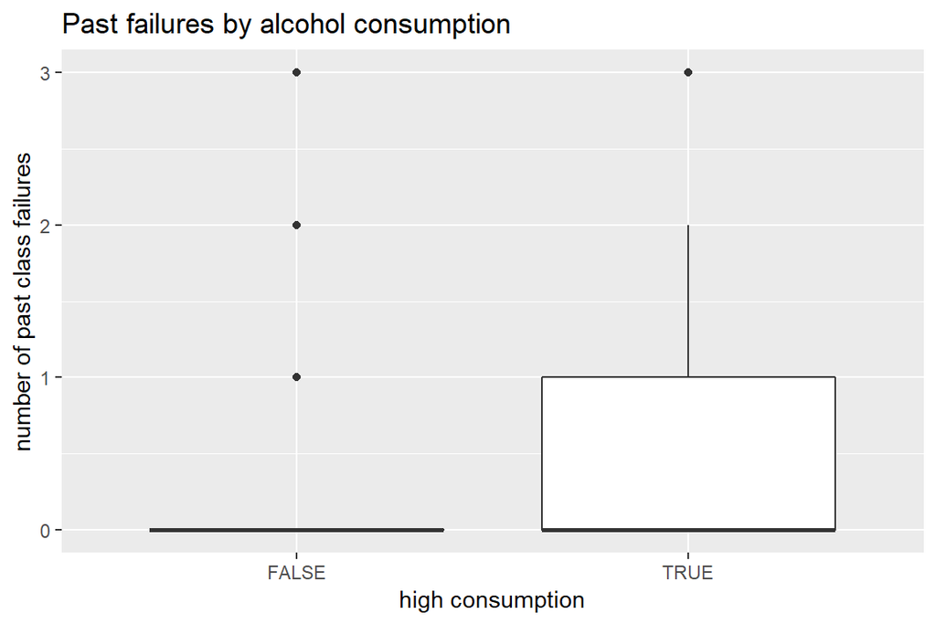

```r
g2 <- ggplot(chapter3analysis, aes(x = high_use, y = failures))

g2 + geom_boxplot() + ggtitle("Past failures by alcohol consumption") + ylab("number of past class failures") + xlab("high consumption")
```

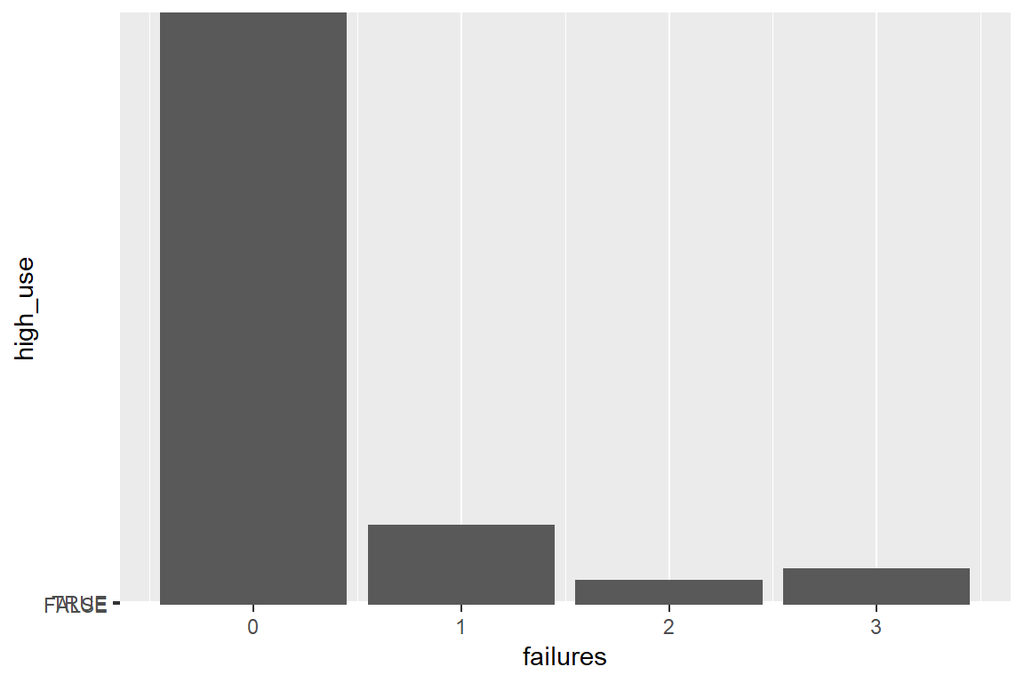

```r
gg2 <-ggplot(data=chapter3analysis, aes(x=failures, y=high_use)) +
  geom_bar(stat="identity")
gg2
```

```r
table(high_use = chapter3analysis$high_use, failures = chapter3analysis$failures)
```

```
##         failures
## high_use   0   1   2   3
##    FALSE 234  22   5   9
##    TRUE   82  16   6   8
```

### 3. Alcohol use and willingness to get higher education

[figure not shown]

```r
g3 <- ggplot(chapter3analysis, aes(x = high_use, y = higher))

g3 + geom_boxplot() + ggtitle("Willingness to get higher education by alcohol consumption") + ylab("wants to take higher education") + xlab("high consumption")
```

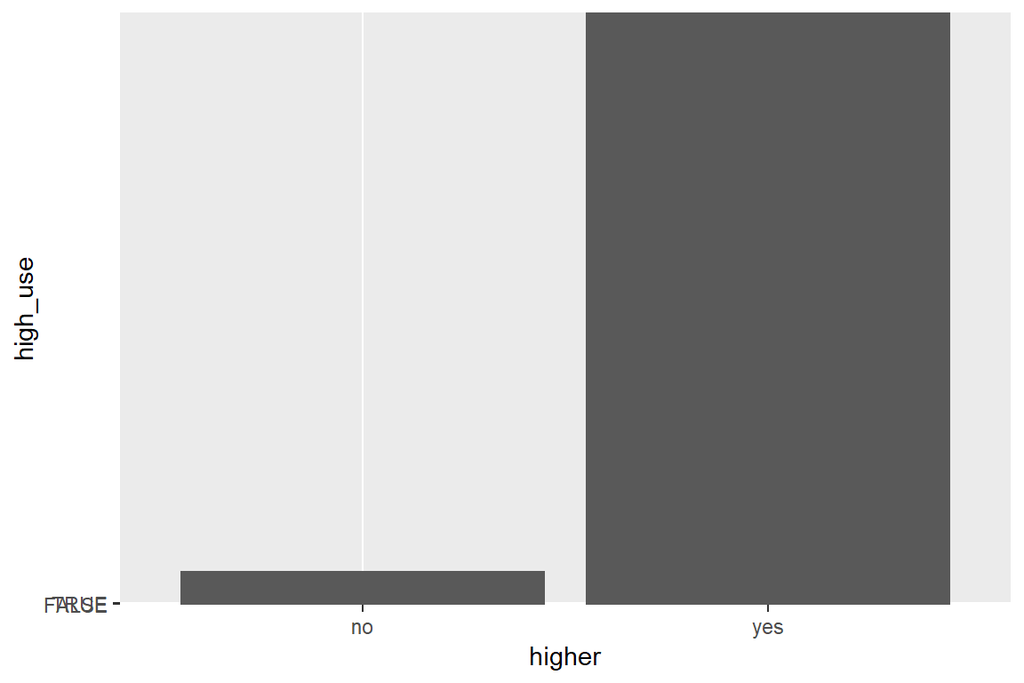

```r
gg3 <-ggplot(data=chapter3analysis, aes(x=higher, y=high_use)) +
  geom_bar(stat="identity")
gg3
```

```r
table(high_use = chapter3analysis$high_use, higher= chapter3analysis$higher)
```

```
##         higher
## high_use  no yes
##    FALSE   9 261
##    TRUE    9 103
```

### 4. Alcohol use and mother’s education

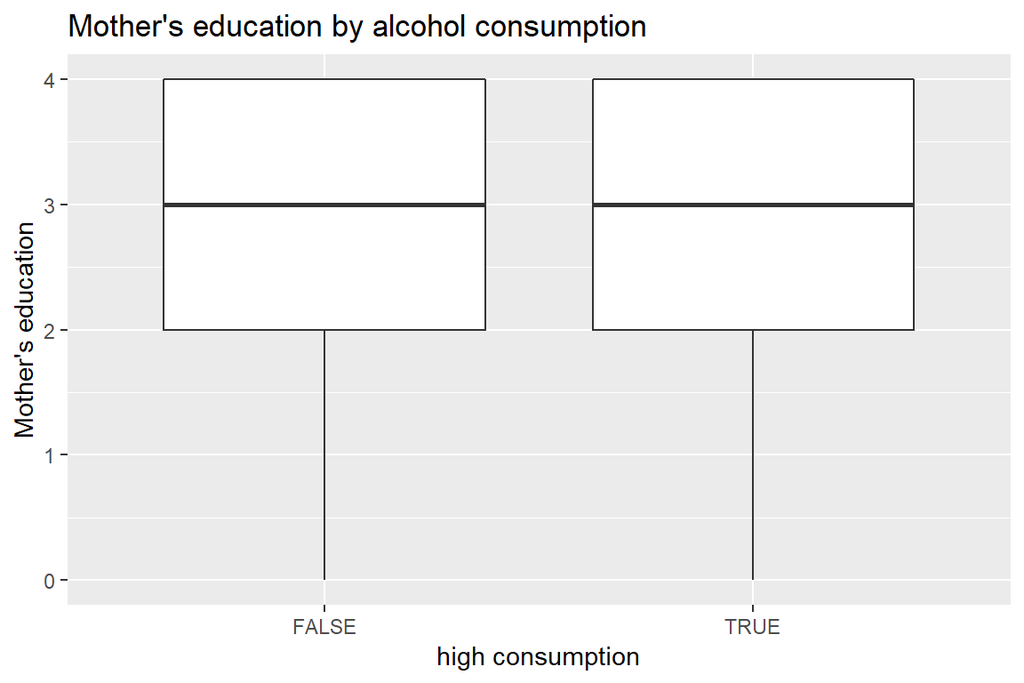

```r
g4 <- ggplot(chapter3analysis, aes(x = high_use, y = Medu))

g4 + geom_boxplot() + ggtitle("Mother's education by alcohol consumption") + ylab("Mother's education") + xlab("high consumption")
```

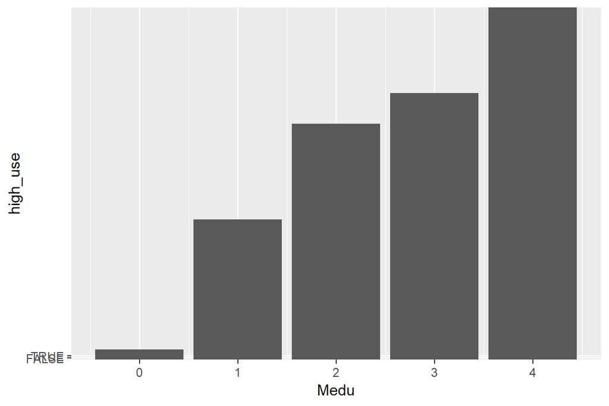

```r
gg4 <-ggplot(data=chapter3analysis, aes(x=Medu, y=high_use)) +
  geom_bar(stat="identity")
gg4
```

```r
table(high_use = chapter3analysis$high_use, Medu = chapter3analysis$Medu)
```

```
##         Medu
## high_use  0  1  2  3  4
##    FALSE  1 33 80 59 97
##    TRUE   2 18 18 36 38
```

## Logistic regression model

The graphical illustrations suggested that we could perhaps reject the null hypothesis in our three first hypotheses. However, before umping to conclusions, let’s run a logistic regression model to see whether there is statistically significant association between the variables.

The regression table below shows that we might have been a bit too hasty with our analysis. The direction of the coefficients studytime, failures and higher do support our initial hypotheses, but only the coefficient on study time is statistically significant (failures is also significant at the 90 % confidence level).

We can reject the null hypothesis only in hypothesis 1, but based on these results, we can argue that hypotheses 2 and 3 are not totally far-fetched.

```r
model1 <- glm(high_use ~ studytime + failures + higher + Medu, data = chapter3analysis, family = "binomial")

summary(model1)
```

```
##
## Call:
## glm(formula = high_use ~ studytime + failures + higher + Medu,
##     family = "binomial", data = chapter3analysis)
##
## Deviance Residuals:
##     Min       1Q   Median       3Q      Max
## -1.4959  -0.8160  -0.7348   1.2767   2.1407
##
## Coefficients:
##             Estimate Std. Error z value Pr(>|z|)
## (Intercept)  0.08657    0.65323   0.133 0.894573
## studytime   -0.54707    0.15636  -3.499 0.000468 ***
## failures     0.31365    0.16194   1.937 0.052771 .
## higheryes   -0.24496    0.54232  -0.452 0.651488
## Medu         0.08095    0.11012   0.735 0.462266
## ---
## Signif. codes:  0 '***' 0.001 '**' 0.01 '*' 0.05 '.' 0.1 ' ' 1
##
## (Dispersion parameter for binomial family taken to be 1)
##
##     Null deviance: 462.21  on 381  degrees of freedom
## Residual deviance: 439.16  on 377  degrees of freedom
## AIC: 449.16
##
## Number of Fisher Scoring iterations: 4
```

```r
coef(model1)
```

```
## (Intercept)   studytime    failures   higheryes        Medu
##  0.08656580 -0.54706597  0.31364704 -0.24496461  0.08095074
```

```r
Oddsratios <- coef(model1) %>% exp

CI <- confint.default(model1) %>% exp

cbind(Oddsratios, CI)
```

```
##             Oddsratios     2.5 %    97.5 %
## (Intercept)  1.0904231 0.3030845 3.9230723
## studytime    0.5786451 0.4259076 0.7861567
## failures     1.3684067 0.9962544 1.8795769
## higheryes    0.7827322 0.2703880 2.2658908
## Medu         1.0843175 0.8738221 1.3455191
```

The confidence intervals of the odd ratio for studytime do not include 1, which confirms us that the coefficient is statistically significant.

The odds ratio for one unit change in study time is about 0.579 (holding the other predictors constant at certain value). As the odds ratio is below 1, we are looking at a negative relationship between study time and alcohol consumption. Using the formula for probability from odds ratios we can calculate the probabilities of being a high user at each study level.

```r
1-(0.5786451/(1+0.5786451))
```

```
## [1] 0.6334546
```

## Predictive power of the model

```r
probabilities <- predict(model1, type = "response")

chapter3analysis <- mutate(chapter3analysis, probability = probabilities)

chapter3analysis <- mutate(chapter3analysis, prediction = probability > 0.5)

select(chapter3analysis, studytime, high_use, probability, prediction) %>% tail(10)
```

```
##     studytime high_use probability prediction
## 373         1    FALSE   0.4229031      FALSE
## 374         1     TRUE   0.4830029      FALSE
## 375         3    FALSE   0.1627789      FALSE
## 376         1    FALSE   0.4057261      FALSE
## 377         3    FALSE   0.2101456      FALSE
## 378         2    FALSE   0.2670428      FALSE
## 379         2    FALSE   0.2977714      FALSE
## 380         2    FALSE   0.2977714      FALSE
## 381         1     TRUE   0.3863662      FALSE
## 382         1     TRUE   0.3863662      FALSE
```

```r
table(high_use = chapter3analysis$high_use, prediction = chapter3analysis$prediction)
```

```
##         prediction
## high_use FALSE TRUE
##    FALSE   261    9
##    TRUE    103    9
```

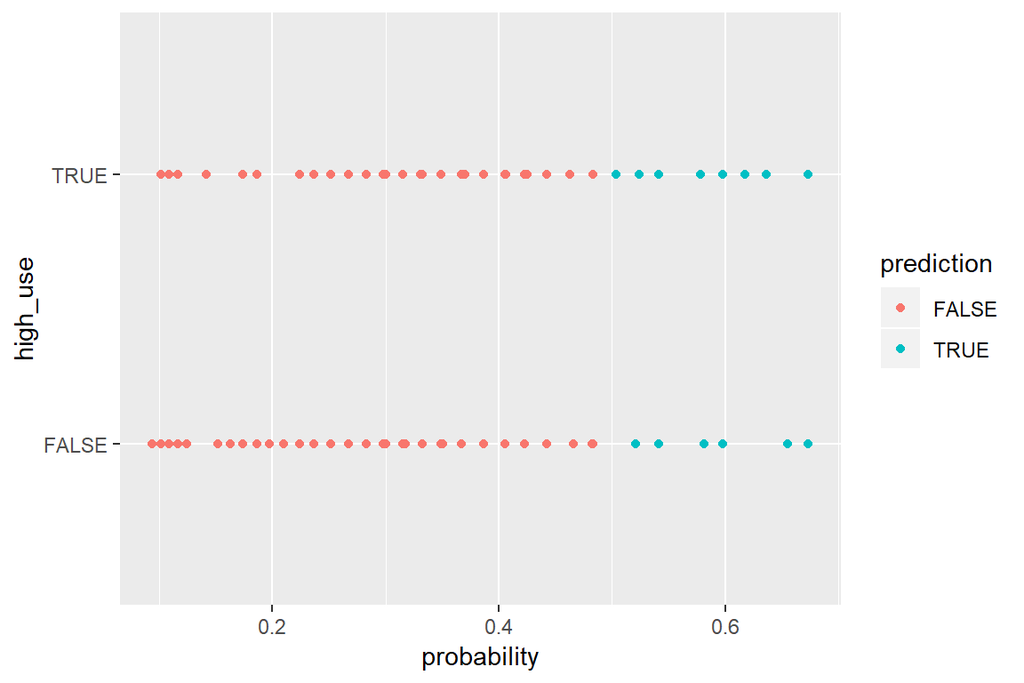

```r
g <- ggplot(chapter3analysis, aes(x = probability, y = high_use, col = prediction))

g + geom_point()
```

```r
table(high_use = chapter3analysis$high_use, prediction = chapter3analysis$prediction) %>% prop.table %>% addmargins
```

```
##         prediction
## high_use      FALSE       TRUE        Sum
##    FALSE 0.68324607 0.02356021 0.70680628
##    TRUE  0.26963351 0.02356021 0.29319372
##    Sum   0.95287958 0.04712042 1.00000000
```

## Cross-validation

```r
loss_func <- function(class, prob) {
  n_wrong <- abs(class - prob) > 0.5
  mean(n_wrong)
}


loss_func(class = chapter3analysis$high_use, prob = chapter3analysis$probability)
```

```
## [1] 0.2931937
```

# Exercise 4

## Data

This time our data includes variables that describe housing values in suburbs of Boston. These are e.g. per capita crime rate, average number of rooms per dwelling and pupil-teacher ratio by town. In total, the data consists of 14 variables and 506 observations.

You can read more about the data from here: https://stat.ethz.ch/R-manual/R-devel/library/MASS/html/Boston.html

The overview of the variables is shown below. Most attention should be paid to variable “medv”“, which describes the median value of the of the owner-occupied homes in thousands of dollars. The values of”medv" range from 5 to 50 with the median 21.20 and mean 22.53. All in all, the variables are in general not normally distributed.

```r
data(Boston)


str(Boston)
```

```
## 'data.frame':    506 obs. of  14 variables:
##  $ crim   : num  0.00632 0.02731 0.02729 0.03237 0.06905 ...
##  $ zn     : num  18 0 0 0 0 0 12.5 12.5 12.5 12.5 ...
##  $ indus  : num  2.31 7.07 7.07 2.18 2.18 2.18 7.87 7.87 7.87 7.87 ...
##  $ chas   : int  0 0 0 0 0 0 0 0 0 0 ...
##  $ nox    : num  0.538 0.469 0.469 0.458 0.458 0.458 0.524 0.524 0.524 0.524 ...
##  $ rm     : num  6.58 6.42 7.18 7 7.15 ...
##  $ age    : num  65.2 78.9 61.1 45.8 54.2 58.7 66.6 96.1 100 85.9 ...
##  $ dis    : num  4.09 4.97 4.97 6.06 6.06 ...
##  $ rad    : int  1 2 2 3 3 3 5 5 5 5 ...
##  $ tax    : num  296 242 242 222 222 222 311 311 311 311 ...
##  $ ptratio: num  15.3 17.8 17.8 18.7 18.7 18.7 15.2 15.2 15.2 15.2 ...
##  $ black  : num  397 397 393 395 397 ...
##  $ lstat  : num  4.98 9.14 4.03 2.94 5.33 ...
##  $ medv   : num  24 21.6 34.7 33.4 36.2 28.7 22.9 27.1 16.5 18.9 ...
```

```r
dim(Boston)
```

```
## [1] 506  14
```

```r
summary(Boston)
```

```
##       crim                zn             indus            chas
##  Min.   : 0.00632   Min.   :  0.00   Min.   : 0.46   Min.   :0.00000
##  1st Qu.: 0.08204   1st Qu.:  0.00   1st Qu.: 5.19   1st Qu.:0.00000
##  Median : 0.25651   Median :  0.00   Median : 9.69   Median :0.00000
##  Mean   : 3.61352   Mean   : 11.36   Mean   :11.14   Mean   :0.06917
##  3rd Qu.: 3.67708   3rd Qu.: 12.50   3rd Qu.:18.10   3rd Qu.:0.00000
##  Max.   :88.97620   Max.   :100.00   Max.   :27.74   Max.   :1.00000
##       nox               rm             age              dis
##  Min.   :0.3850   Min.   :3.561   Min.   :  2.90   Min.   : 1.130
##  1st Qu.:0.4490   1st Qu.:5.886   1st Qu.: 45.02   1st Qu.: 2.100
##  Median :0.5380   Median :6.208   Median : 77.50   Median : 3.207
##  Mean   :0.5547   Mean   :6.285   Mean   : 68.57   Mean   : 3.795
##  3rd Qu.:0.6240   3rd Qu.:6.623   3rd Qu.: 94.08   3rd Qu.: 5.188
##  Max.   :0.8710   Max.   :8.780   Max.   :100.00   Max.   :12.127
##       rad              tax           ptratio          black
##  Min.   : 1.000   Min.   :187.0   Min.   :12.60   Min.   :  0.32
##  1st Qu.: 4.000   1st Qu.:279.0   1st Qu.:17.40   1st Qu.:375.38
##  Median : 5.000   Median :330.0   Median :19.05   Median :391.44
##  Mean   : 9.549   Mean   :408.2   Mean   :18.46   Mean   :356.67
##  3rd Qu.:24.000   3rd Qu.:666.0   3rd Qu.:20.20   3rd Qu.:396.23
##  Max.   :24.000   Max.   :711.0   Max.   :22.00   Max.   :396.90
##      lstat            medv
##  Min.   : 1.73   Min.   : 5.00
##  1st Qu.: 6.95   1st Qu.:17.02
##  Median :11.36   Median :21.20
##  Mean   :12.65   Mean   :22.53
##  3rd Qu.:16.95   3rd Qu.:25.00
##  Max.   :37.97   Max.   :50.00
```

```r
glimpse(Boston)
```

```
## Observations: 506
## Variables: 14
## $ crim    <dbl> 0.00632, 0.02731, 0.02729, 0.03237, 0.06905, 0.02985, ...
## $ zn      <dbl> 18.0, 0.0, 0.0, 0.0, 0.0, 0.0, 12.5, 12.5, 12.5, 12.5,...
## $ indus   <dbl> 2.31, 7.07, 7.07, 2.18, 2.18, 2.18, 7.87, 7.87, 7.87, ...
## $ chas    <int> 0, 0, 0, 0, 0, 0, 0, 0, 0, 0, 0, 0, 0, 0, 0, 0, 0, 0, ...
## $ nox     <dbl> 0.538, 0.469, 0.469, 0.458, 0.458, 0.458, 0.524, 0.524...
## $ rm      <dbl> 6.575, 6.421, 7.185, 6.998, 7.147, 6.430, 6.012, 6.172...
## $ age     <dbl> 65.2, 78.9, 61.1, 45.8, 54.2, 58.7, 66.6, 96.1, 100.0,...
## $ dis     <dbl> 4.0900, 4.9671, 4.9671, 6.0622, 6.0622, 6.0622, 5.5605...
## $ rad     <int> 1, 2, 2, 3, 3, 3, 5, 5, 5, 5, 5, 5, 5, 4, 4, 4, 4, 4, ...
## $ tax     <dbl> 296, 242, 242, 222, 222, 222, 311, 311, 311, 311, 311,...
## $ ptratio <dbl> 15.3, 17.8, 17.8, 18.7, 18.7, 18.7, 15.2, 15.2, 15.2, ...
## $ black   <dbl> 396.90, 396.90, 392.83, 394.63, 396.90, 394.12, 395.60...
## $ lstat   <dbl> 4.98, 9.14, 4.03, 2.94, 5.33, 5.21, 12.43, 19.15, 29.9...
## $ medv    <dbl> 24.0, 21.6, 34.7, 33.4, 36.2, 28.7, 22.9, 27.1, 16.5, ...
```